# Contiguous Rainfall Area (CRA) Analysis Using R

Raghavendra Ashrit, Anumeha Dube and Greeshma Mohan

#### *raghu@ncmrwf.gov.in ; anumeha@ncmrwf.gov.in ; greeshma@ncmrwf.gov.in*

08 May 2023

Contiguous Rainfall Area (CRA) is an entity based verifcation method developed by Ebert, E. E., and McBride, J. L. (2000). A CRA is defined for an observation-forecast pair based on user specified rainfall threshold and union of the forecast and observed rain entities. This method quantifies the systematic bias in the model in predicting the rainfall and dissociates it into different error components. The CRA analysis technique is well desribed in Ebert, E. E., and Gallus, W. A. (2009).

A brief summary of the CRA analysis procedure based on the minmization of the mean squared error (MSE) is given below,

- Identification and pairing of the objects: The rainfall objects based on a defined threshold is identified from both forecast and observation using `FeatureFinder` from the `SpatialVx` package. The objects which are close by 5 gridcells are paired and objects which are smaller in area are ignored.
- Calculation of the geometric distance between the centers of gravity (COG), mean square error and correlation between the identified objects.
- The model field is translated over the CRA until a best match is obtained through the minimization of the MSE
- The total error (MSE<sub>Total</sub>) decomposes into different components Ebert, E. E., and McBride, J. L. (2000).

$$\tag{1}
MSE_{Total} = MSE_{Displacement} + MSE_{Volume} + MSE_{Pattern}$$

The details on this package and the step-by-step instructions are described below.

**1. Introduction to craR.**  
craR includes the following files

- **Isolate_Objects.R :** Function to identify and pair rainfall objects from both model and observation based on rainfall threshold. This will provide each objects in separate NetCDF file.
- **CRA_Err_Decomp_Features.R :** Main function for CRA analysis
- **Func_Run_CRA_Analysis.sh :** This is a shell script which creates a R script which does CRA analysis for all the identified model-observation object pairs from the domain. Both of the aforementioned functions are used in this.
- **Run_CRA_Plot.sh :** Creates figure including the necessary statistics tables
- **obs_20210517.nc :** Test data for observation
- **model_20210517.nc :** Test data for model forecast
- **output :** This directory includes the output of this test case
- **ReadMe.txt :**

This package has been tested on R version 3.4.3 and the list of libraries required for the CRA analysis and plotting are listed below.

```r
library(raster)
library(SpatialVx)

###libraries required for plotting
library(gridExtra)
library(grid)
library(formattable)
library("RColorBrewer")
library(fields)
library(rgdal)
```

**2. Read the observation and model forecast rainfall data as rasters**

```r
orf <- raster("obs_20210517.nc")
mrf <- raster("model_20210517.nc")
```

To view the spatial distribution of rainfall from model and observation,

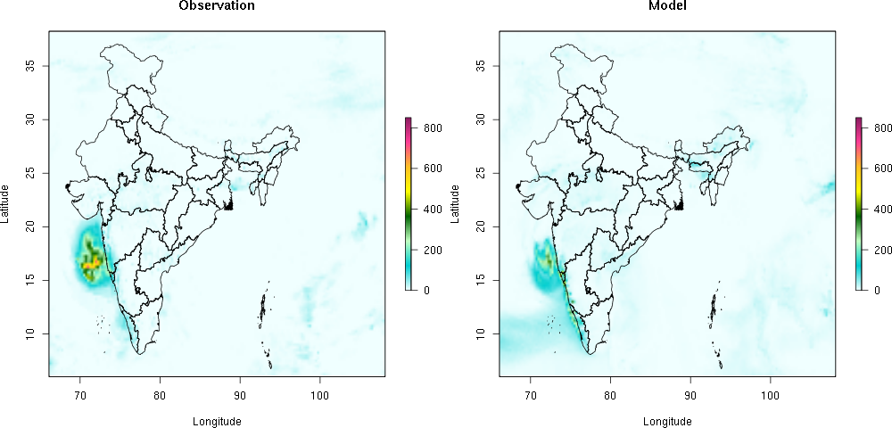

```r
shp <- readOGR(dsn = file.path("IND_WHOLE.shp"), stringsAsFactors = F)
mycols=c("azure","darkturquoise","darkseagreen1","darkgreen","yellow","goldenrod1","violetred1","maroon4")
myrange=colorRampPalette(mycols)
mycrange=myrange(850)
mycols = mycrange[c(0:850)]

plot(orf, xlim=c(66, 108), ylim=c(6, 38), zlim=c(0,850), xlab = "Longitude",
     ylab = "Latitude", interpolate=TRUE, col=mycols, xaxs="i", yaxs="i",
     asp=1, legend=TRUE, main="Observation")
plot(shp,add=TRUE)

plot(mrf, xlim=c(66, 108), ylim=c(6, 38), zlim=c(0,850), xlab = "Longitude",
     ylab = "Latitude", interpolate=TRUE, col=mycols, xaxs="i", yaxs="i",
     asp=1, legend=TRUE, main="Model")
plot(shp,add=TRUE)
```

**3. Define the threshold rainfall**  
To identify the rainfall objects from model and observation threshold rainfall has to be defined in mm/day

```r
Threshold<-40
```

**4. The identification of rainfall objects**  
The `Isolate_Objects.R` identifies the rainfall objects and save them into NetCDF format. More details on the input arguments are given in Annexure.

```r
source("Isolate_Objects.R")
Isolate_Objects("obs_20210517.nc","model_20210517.nc","Obj_Obs","Obj_Model",thr=40,minsize=30,sepdist=5)
```

The isolated objects are saved as Obj_Obs_Object1.nc and Obj_Model_Object1.nc from observation and model forecast respectively.  
**5. CRA Analysis**  
Using the aforementioned object files the errors are calculated using `CRA_Err_Decomp` function as follows. More details on the input arguments are given in Annexure.

```r
source("CRA_Err_Decomp_Features.R")
CRA_Err_Decomp("obs_20210517.nc","model_20210517.nc","Obj_Obs_Object1.nc","Obj_Model_Object1.nc",thr=40,objnum=1,"20210517_Thr40_CTL",Ngrids=6)
```

The `CRA_Err_Decomp_Features.R` produces a set of ASCII files with a defined prefix (Here, 20210517_Thr40_CTL*.txt).

- **20210517_Thr40_CTL_1_xydistcog.txt :** Distance (in km) between the centre of gravity before and after shifting
- **20210517_Thr40_CTL_1_cra_decomp.txt :** CRA error components (%)
- **20210517_Thr40_CTL_1_cog.txt :** centre of gravity in terms of latitude and longitude before and after shifting the model
- **20210517_Thr40_CTL_1_StatsOrig.txt :** Stats (no. of points, average rainfall, maximum rainfall, rain volume, and area) from both observation and before shifting the model
- **20210517_Thr40_CTL_1_ScatterData.txt :** Data to plot scatter diagram
- **20210517_Thr40_CTL_1_AllStats.txt :** All stats (no. of points, average rainfall, maximum rainfall, rain volume, area, RMSE and correleation) from observation and after shifting the model field

**6. Plotting the statistics**  
The final CRA plot with all the statistics before and after the shift of the model raster over the CRA area can be plotted using `Run_CRA_Plot.sh`.

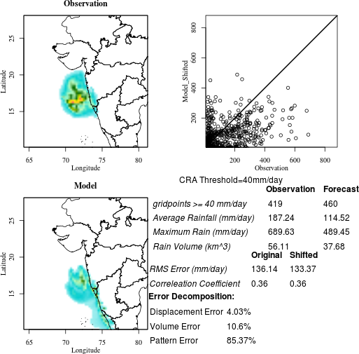

**7. CRA Analysis for multiple objects**  
One can use `Func_Run_CRA_Analysis.sh`, if multiple paired objects are to be analysed over the same domian. More details on this script can be found in ReadMe.txt.

## Annexure

```
Isolate_Objects(ActOrf,ActMrf,objOBS,objMODEL,thr,minsize,sepdist)

#User inputs for this function are:
#----------------------------------#
#ActOrf  : Actual observation
#ActMrf  : Actual model
#objOBS  : prefix for the object NetCDF file from observation
#objMODEL: prefix for the object NetCDF file from model
#thr     : Threshold rainfall
#minsize : The minum area of the object to be considered for the analysis. At present it is kept as 30
#sepdist : The number of grids to be considered for merging the objects. At present it is kept as 5
```

```
CRA_Err_Decomp(ActOrf,ActMrf,orf,mrf,thr,objnum,out_prefix,Ngrids)

#User inputs for the function are:
#---------------------------------#
#ActOrf    : Actual observation
#ActMrf    : Actual model
#orf       : object1 from observation
#mrf       : object1 from model
#thr       : Threshold rainfall
#objnum    : serial number of the object
#out_prefix: prefix of the output file
#Ngrids    :number of grids of model translation over CRA area. At present it is kept as 6*
```

## References:

Dube, A., Karunasagar, S., Ashrit, R., and Mitra, A. K., 2022. Spatial verification of ensemble rainfall forecasts over india.

Ebert, E. E., and Gallus, W. A., 2009. Towards better understanding of contiguous rain areas (cra) method of spatial verification.

Ebert, E. E., and McBride, J. L., 2000. Verification of precipitation in weather systems: Determination of systematic errors.

Sharma, K., Ashrit, R., Ebert, E., Iyengar, G., and Mitra, A., 2015. NGFS rainfall forecast verification over india using the contiguous rain area (cra) method.

Sharma, K., Ashrit, R., Ebert, E., Mitra, A., Bhatla, R., Iyengar, G., and Rajagopal, E. N., 2019. Assessment of met office unified model (um) quantitative precipitation forecasts during the indian summer monsoon: Contiguous rain area (cra) approach.